# Kansas Choropleth Map

Mark White | markwhiteii@gmail.com

## Preparation

This document will explain how to use the `ks_map` function, which will return a choropleth map at the county level for Kansas. Before I go any further, please note that this function requires the following packages: `ggplot2`, `ggmap`, `maps`, `dplyr`, and `tidyr`. If you want to load the function into your current R session, you can use the following code:

```r
source("path/to/the/file/ks_map.R")
```

Where “path/to/the/file” is the directory where you have stored the R file `ks_map.R`. After this, the function will be loaded into your session to use.  
It also requires a certain data structure: A variable needs to be labeled “fips” (with five-digit county FIPS codes) or labeled “county” (with county names, in all lowercase); additionally, it requires some numeric vector whose values you will use to fill in the choropleth map. Consider the following data frame:

```r
head(test)
```

```
##    fips   county           var
## 1 20001    allen  1.2361964796
## 2 20003 anderson -1.4832778353
## 3 20005 atchison  0.9411606117
## 4 20007   barber -0.0003063087
## 5 20009   barton -2.3570193706
## 6 20011  bourbon  0.7802902128
```

There can certainly be more variables than the required ones, but the function only interacts with these two.

## Using the function

The function looks like this:

```r
ks_map(data, key, variable, label="", lowcolor="#56B1F7", highcolor="#132B43", title="")
```

The parameters are:  
1. `data` = the data frame containing the variables you want to map.  
2. `key` = either “fips” or “county.” The function will throw an error if the key is not set to one of these two. It should be specified as a character string.  
3. `variable` = the variable you want to use as the fill for each county. This should be supplied as a character string.  
4. `label` = the legend title you wish to have; the label for your variable. This defaults to being blank.  
5. `lowcolor` = the color you wish to represent the minimum value of `variable`. This takes a hex value (or a string known by R) as a character string. It defaults to the `ggplot2` default.  
6. `highcolor` = the color you wish to represent the maximum value of `variable`. This takes a hex value (or a string known by R) as a character string. It defaults to the `ggplot2` default.  
7. `title` = the title that will go above your map. This defaults to being blank.

## Examples

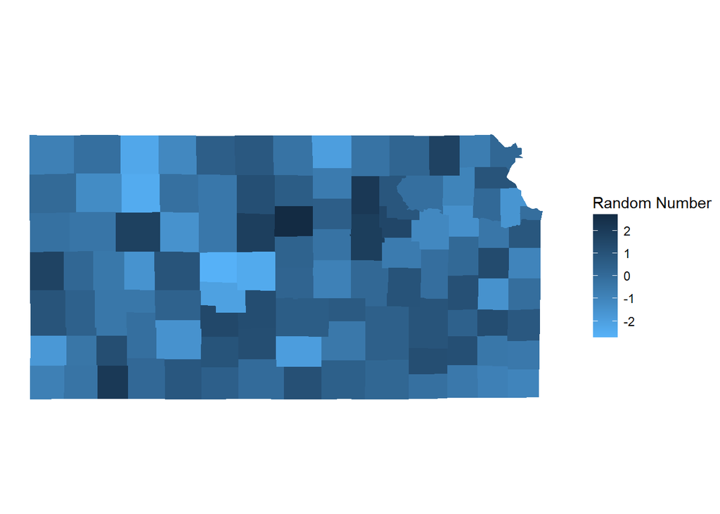

```r
ks_map(data=test, key="fips", variable="var", label="Random Number")
```

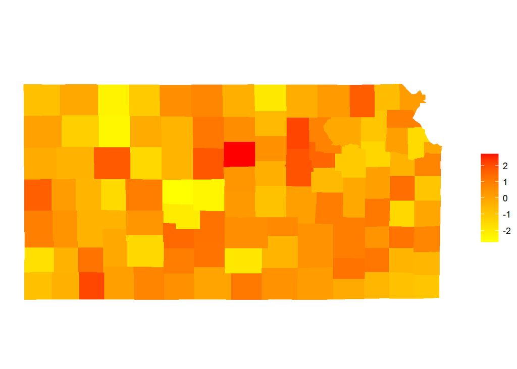

```r
ks_map(data=test, key="county", variable="var", lowcolor="yellow", highcolor="red")
```

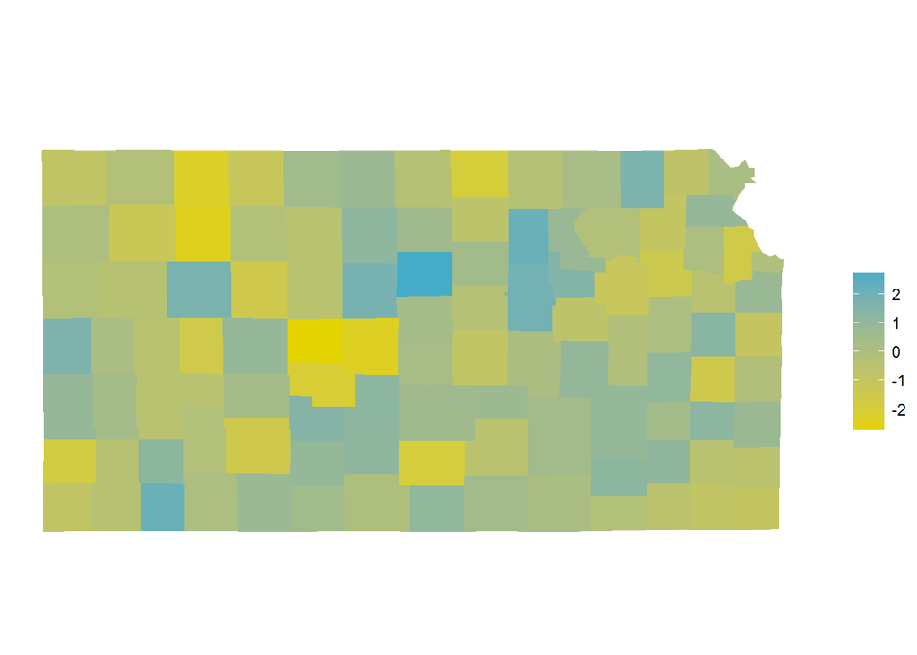

```r
ks_map(data=test, key="county", variable="var", lowcolor="#E2D200", highcolor="#46ACC8")
```